# Loading and preprocessing the data

## Loading and preprocessing the data

First we unzip the data te get acess to csv vile inside archive:

```r
unzip('activity.zip')
```

The next step is to load some libraries we need to process the data:

```r
library(ggplot2)
library(scales)
library(reshape2)
```

Read data from the disk:

```r
activity <- read.csv('activity.csv')
```

Initial dataset consists of following columns:

1. **steps**: Number of steps taking in a 5-minute interval (missing values are coded as `NA` )
2. **date**: The date on which the measurement was taken in YYYY-MM-DD format
3. **interval**: Identifier for the 5-minute interval in which measurement was taken

```r
names(activity)
```

```
## [1] "steps"    "date"     "interval"
```

```r
str(activity)
```

```
## 'data.frame':    17568 obs. of  3 variables:
##  $ steps   : int  NA NA NA NA NA NA NA NA NA NA ...
##  $ date    : Factor w/ 61 levels "2012-10-01","2012-10-02",..: 1 1 1 1 1 1 1 1 1 1 ...
##  $ interval: int  0 5 10 15 20 25 30 35 40 45 ...
```

```r
head(activity)
```

```
##   steps       date interval
## 1    NA 2012-10-01        0
## 2    NA 2012-10-01        5
## 3    NA 2012-10-01       10
## 4    NA 2012-10-01       15
## 5    NA 2012-10-01       20
## 6    NA 2012-10-01       25
```

We need to perform some initial steps after loading data. We will transform interval column into factor variable, add levels on it, and add new data.POSIXlt format column:

```r
activity.interval.levels <- sprintf(
        "%04i",
        sort(unique(activity$interval))
    )
activity.date.levels <- sort(unique(as.character(activity$date)))
activity$interval <- sprintf("%04i", activity$interval)
activity$interval <- factor(
        activity$interval,
        levels = activity.interval.levels
    )
activity$date <- factor(activity$date, levels = activity.date.levels)
activity$time <- as.POSIXlt(
        paste(activity$date, activity$interval, sep = " "),
        format = "%Y-%m-%d %H%M"
    )
```

Columns' description:

1. **steps**: Number of steps taking in a 5-minute interval (missing values are coded as `NA`)
2. **date**: The date on which the measurement was taken in YYYY-MM-DD format
3. **interval**: Identifier for the 5-minute interval in which measurement was taken in HHmm format
4. **time**: identifier of 5-minute interval in POSIXlt format

```r
names(activity)
```

```
## [1] "steps"    "date"     "interval" "time"
```

```r
str(activity)
```

```
## 'data.frame':    17568 obs. of  4 variables:
##  $ steps   : int  NA NA NA NA NA NA NA NA NA NA ...
##  $ date    : Factor w/ 61 levels "2012-10-01","2012-10-02",..: 1 1 1 1 1 1 1 1 1 1 ...
##  $ interval: Factor w/ 288 levels "0000","0005",..: 1 2 3 4 5 6 7 8 9 10 ...
##  $ time    : POSIXlt, format: "2012-10-01 00:00:00" "2012-10-01 00:05:00" ...
```

```r
head(activity)
```

```
##   steps       date interval                time
## 1    NA 2012-10-01     0000 2012-10-01 00:00:00
## 2    NA 2012-10-01     0005 2012-10-01 00:05:00
## 3    NA 2012-10-01     0010 2012-10-01 00:10:00
## 4    NA 2012-10-01     0015 2012-10-01 00:15:00
## 5    NA 2012-10-01     0020 2012-10-01 00:20:00
## 6    NA 2012-10-01     0025 2012-10-01 00:25:00
```

## What is mean total number of steps taken per day?

Summarize total number of steps for aech day by:

```r
steps.day <- as.data.frame(
        tapply(
            activity$steps,
            activity$date,
            sum,
            na.rm = TRUE
        )
    )
colnames(steps.day) <- c("steps")
```

Calculate average and medium number of steps:

```r
mean(steps.day$steps)
```

```
## [1] 9354.23
```

```r
median(steps.day$steps)
```

```
## [1] 10395
```

Make a histogram of the total number of steps taken each day and add mean (red color) and median (gren color) vertical lines:

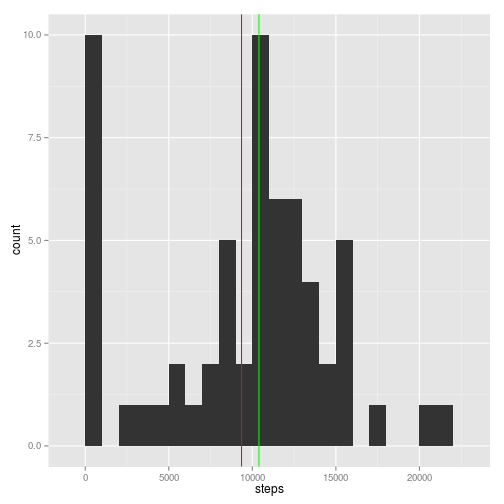

```r
ggplot(steps.day, aes(x = steps)) +
    geom_histogram(
        binwidth = 1000
    ) +
    geom_vline(
        xintercept = mean(steps.day$steps),
        show_guide = TRUE,
        labels = "Mean",
        color = "Red"
    ) +
    geom_vline(
        xintercept = median(steps.day$steps),
        show_guide = TRUE,
        labels = "Median",
        color = "Green"
    )
```

## What is the average daily activity pattern?

To calculate daily activity pattern we will apply mean function to measurements with the same interval value:

```r
steps.mean <- as.data.frame(
        tapply(
            activity$steps,
            activity$interval,
            mean,
            na.rm = TRUE
        )
    )
colnames(steps.mean) <- c("steps.mean")
steps.mean$interval <- row.names(steps.mean)
steps.mean$time <- as.POSIXlt(steps.mean$interval, format = "%H%M")
```

Find the 5-minute interval contains the maximum number of steps average across all the days in the dataset is:

```r
max.steps.mean <- data.frame(
        steps.mean[
            steps.mean$steps.mean == max(steps.mean$steps.mean),
            "time"
        ],
        max(steps.mean$steps.mean)
    )
colnames(max.steps.mean)<-c("interval", "steps")
format(max.steps.mean, format = "%H:%M")
```

```
##   interval    steps
## 1    08:35 206.1698
```

Draw the time series plot. The maximum number of steps is a red dot:

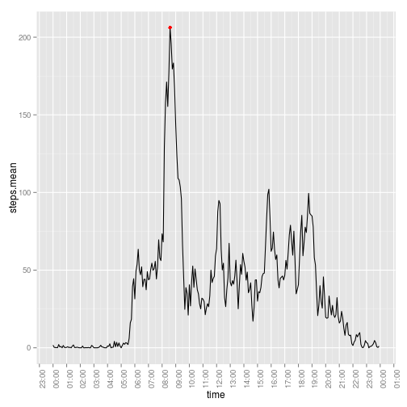

```r
ggplot(steps.mean, aes(x = time, y = steps.mean)) +
    geom_line() +
    scale_x_datetime(
        labels = date_format("%H:%M"),
        breaks = date_breaks("1 hour")
    ) +
    theme(
        axis.text.x = element_text(angle = 90, hjust = 1)
    ) +
    geom_point(
        data = max.steps.mean,
        aes(x = interval,y = steps),
        color = "red"
    )
```